# Modern Data Structure HW02

Xueying Huang

2019-09-27

```r
library(tidyverse)
library(tidyr)
library(dplyr)
library(readr)

rawData <- read_csv("U.S._Chronic_Disease_Indicators__CDI_.csv",col_names = TRUE)
cleanData <- rawData %>%
  filter(Question == "Binge drinking prevalence among adults aged >= 18 years" | Question == "Poverty") %>%
  filter(DataValueType == "Crude Prevalence") %>%
  filter(StratificationCategory1 == "Overall" | StratificationCategory1 == "Gender") %>%
  filter((Question == "Poverty" & StratificationCategory1 == "Overall" )|(Question == "Binge drinking prevalence among adults aged >= 18 years" )) %>%
  select(LocationDesc, LocationAbbr, YearStart, Question, DataValueAlt,Stratification1) %>%
  group_by(YearStart, LocationDesc) %>%
  spread(key = Stratification1, value = DataValueAlt)

cleanData_poverty <- cleanData %>%
  filter(Question == "Poverty") %>%
  select(state = LocationDesc, stateabb = LocationAbbr, year = YearStart, poverty = Overall)

cleanData_drink <- cleanData %>%
  filter(Question == "Binge drinking prevalence among adults aged >= 18 years") %>%
  select(state = LocationDesc, stateabb = LocationAbbr, year = YearStart, binge_all = Overall, binge_male = Male, binge_female = Female)

tidyData <- full_join(cleanData_drink,cleanData_poverty, by = c("state", "stateabb", "year"))
write.csv(tidyData, file = "binge_clean.csv", row.names = FALSE)
```

```r
yeartable <- tidyData %>%
 arrange(desc(year))
bingeDrink <- tidyData %>%
  filter(year == yeartable[1,"year"]) %>%
  select(state, year, binge_all, binge_male, binge_female) %>%
  arrange(desc(binge_all))
head(bingeDrink, 10)
```

```
## # A tibble: 10 x 5
## # Groups:   year, state [10]
##    state                 year binge_all binge_male binge_female
##    <chr>                <dbl>     <dbl>      <dbl>        <dbl>
##  1 District of Columbia  2016      25.6       30.5         21.3
##  2 North Dakota          2016      24.8       32.1         17.2
##  3 Wisconsin             2016      24.6       29.7         19.5
##  4 Minnesota             2016      21.3       26.5         16.2
##  5 Iowa                  2016      21.2       27.1         15.4
##  6 Guam                  2016      20.7       29.8         11.2
##  7 Nebraska              2016      20         27.2         13.1
##  8 Illinois              2016      19.9       25.6         14.5
##  9 Pennsylvania          2016      19.4       25.3         13.8
## 10 South Dakota          2016      19.3       24.3         14.3
```

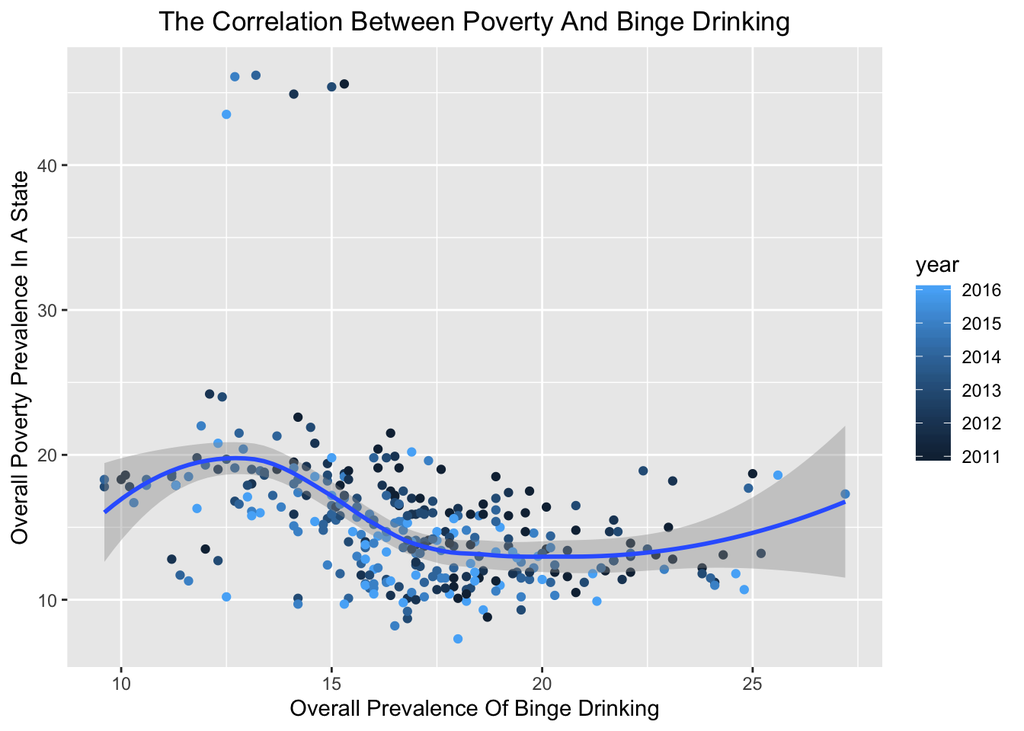

```r
library(ggplot2)
tidyData_na <- na.omit(tidyData)
ggplot(tidyData_na, aes(x = binge_all, y = poverty, color = year)) + geom_point() + geom_smooth(method = "loess") + labs(title="The Correlation Between Poverty And Binge Drinking", x="Overall Prevalence Of Binge Drinking", y="Overall Poverty Prevalence In A State")+ theme(plot.title = element_text(hjust = 0.5))
```

Comment: I used all years and highlight them by color. 1) We noticed that the prevalence of poverty in the states was relatively high when the binge drinking prevalence was less than 15% or more than 25%. For some states which have high poverty prevalence, citizens did not have spared money to buy wine/beer, so the binge drinking prevalence was low in those states. As the prevalence of poverty decreased, the citizens owned more available money to spend on social events, which caused the increase of binge drink prevalence. However, when the binge drinking prevalence exceeded 25%, poverty prevalence reached another high peak because excessive drinking might impact the normal work and life negatively, which resulted in prevalence of poverty. 2) From 2011 to 2016, when the binge drinking prevalence keeped the same, the poverty prevalence has a decreasing trend in most states, which might resulted from the upward of global economy.

```r
library(dplyr)
 growthData_avg <- tidyData_na %>%
  group_by(state) %>%
  summarize(total_growth_rate = last(binge_all, order_by = year)-first(binge_all, order_by = year), firstyear_rate = first(binge_all, order_by = year), period = max(year) - min(year) + 1) %>%
   mutate(avg_growth_rate = total_growth_rate / (firstyear_rate*period)*100, dataValueUnit = '%') %>%
   select(state, avg_growth_rate, dataValueUnit) %>%
   arrange(desc(avg_growth_rate))
 biggest_increase <- head(growthData_avg, 5)
 biggest_decrease <- tail(growthData_avg, 5) %>%
   arrange(avg_growth_rate)
 biggest_increase
```

```
## # A tibble: 5 x 3
##   state          avg_growth_rate dataValueUnit
##   <chr>                    <dbl> <chr>
## 1 Tennessee                 5.17 %
## 2 West Virginia             1.98 %
## 3 South Carolina            1.52 %
## 4 Arkansas                  1.06 %
## 5 Pennsylvania              1.00 %
```

```r
 biggest_decrease
```

```
## # A tibble: 5 x 3
##   state        avg_growth_rate dataValueUnit
##   <chr>                  <dbl> <chr>
## 1 Oklahoma               -4.75 %
## 2 Georgia                -3.31 %
## 3 Rhode Island           -3.23 %
## 4 Puerto Rico            -3.05 %
## 5 Delaware               -2.71 %
```